# IS 606 - Project 1

H. Berk, S. Hong, R. Srinivasan, J. Hamski

March 4, 2015

**Report For: James’s Sandwich Stand**

Per our group consulting services agreement, please find this quantitative analysis on sandwich stand operations and inventory control for James’s Sandwich Stand below. The goal of this report is to determine how many sandwiches of each type James’s Sandwich Stand should bring each day in order to maximize expected profits.

Our consulting group was provided with two datasets:  
1. The daily sales data, containing the number brought and number demanded for each sandwich over 130 days  
2. Pricing data, containing the cost and sale price of each type of sandwich

```r
profit.margin <- data.frame(details$price - details$cost, row.names = c("ham", "turkey", "veggie"))
kable(profit.margin)
```

|  | details.price…details.cost |
| --- | --- |
| ham | 3.0 |
| turkey | 2.5 |
| veggie | 2.5 |

Calculating Profit using an R function

```r
profit.func <- function(demand.sim,inventory.sim){
  profit.sim.func <- ifelse(demand.sim-inventory.sim<=0,demand.sim*3.0-(inventory.sim-demand.sim)*3.5, inventory.sim*3.0)
  profit.sim.func<-sum(profit.sim.func)
  return(profit.sim.func)}
```

We can test to make sure the observed profits match previous calculations in Excel

```r
(obs.profit<-profit.func(sales$demand.ham, sales$available.ham))
```

```
## [1] 4837
```

For ham, what hits profits harder - foregone sales or unused inventory?

```r
ham.bal <- sales$demand.ham - sales$available.ham
foregone.sales <- ifelse(ham.bal>0, (sales$demand.ham-sales$available.ham)*6.5,0)
unused.inventory <- ifelse(ham.bal<0, (sales$available.ham - sales$demand.ham)*3.5, 0)
(sum(foregone.sales))
```

```
## [1] 1462.5
```

```r
(sum(unused.inventory))
```

```
## [1] 707
```

Conclusion -> foregone sales hurts profit more than unused inventory. Perhaps we can use this to form a better inventory strategy.

First, in order to test a inventory we create a simulation of sandwich demand. Then, we simulate different inventory strategies (“number of sandwiches per day per type”) and calculate their effects on profit. We assume that demand for each sandwich type is independent. Therefore, a strategy that increases profit for ham sandwiches will have no effect on turkey or veggie sandwich profits. This reasonable assumption of independence greatly simplifies the model.

We can model sandwich demand using a Poisson distribution.

## For Ham:

Calculate lambda using the mean of ham demand (no. of sandwiches per day).

```r
lambda.ham <- mean(sales$demand.ham)
```

then, using a Poisson function, we simulate the demand of sandwiches for each day of a 130 day period

```r
demand.sim <- sapply(1:130, function(x) rpois(1,lambda.ham))
```

Comparing the histograms of the ham demand simulation and the empirical sales demand, we note that the look similar.

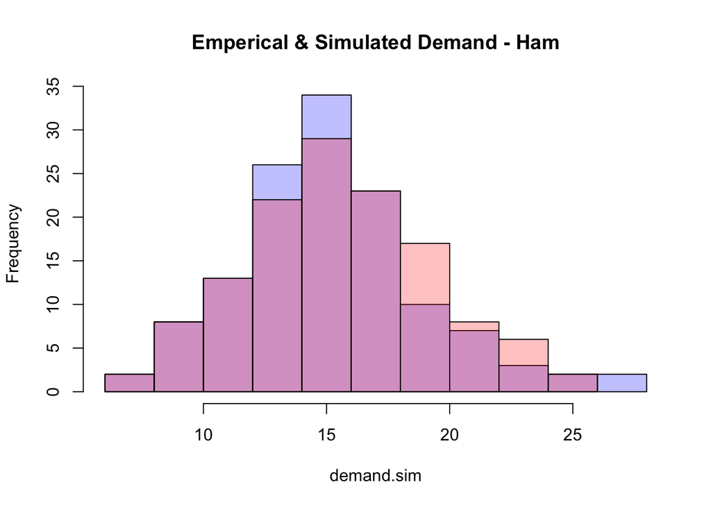

```r
hist(demand.sim, col=rgb(0,0,1,1/4), main ="Emperical & Simulated Demand - Ham")
hist(sales$demand.ham,col=rgb(1,0,0,1/4), ylim = 30, add=TRUE)
```